# Google Data Analytics Case Study

Ahad Mohammad

2025-02-25

## Setting up my environment

```r
install.packages("tidyverse")
install.packages("janitor")
install.packages("skimr")
```

## Loading Packages

```r
library(tidyverse)
library(janitor)
library(skimr)
```

## Importing Data

```r
p1_daily_activity <- read.csv("mturkfitbit_export_3.12.16-4.11.16/Fitabase Data 3.12.16-4.11.16/dailyActivity_merged.csv")
p2_daily_activity <- read.csv("mturkfitbit_export_4.12.16-5.12.16/Fitabase Data 4.12.16-5.12.16/dailyActivity_merged.csv")
p1_hourly_calories <- read.csv("mturkfitbit_export_3.12.16-4.11.16/Fitabase Data 3.12.16-4.11.16/hourlyCalories_merged.csv")
p2_hourly_calories <- read.csv("mturkfitbit_export_4.12.16-5.12.16/Fitabase Data 4.12.16-5.12.16/hourlyCalories_merged.csv")
p2_day_sleep <- read.csv("mturkfitbit_export_4.12.16-5.12.16/Fitabase Data 4.12.16-5.12.16/sleepDay_merged.csv")
```

## Merging Datasets

```r
daily_activity <- rbind(p1_daily_activity,p2_daily_activity)
hourly_calories <- rbind(p1_hourly_calories,p2_hourly_calories)
day_sleep <- p2_day_sleep
```

## Checking Data

Checking column names and data types

```r
str(daily_activity)
```

```
## 'data.frame':    1397 obs. of  15 variables:
##  $ Id                      : num  1.5e+09 1.5e+09 1.5e+09 1.5e+09 1.5e+09 ...
##  $ ActivityDate            : chr  "3/25/2016" "3/26/2016" "3/27/2016" "3/28/2016" ...
##  $ TotalSteps              : int  11004 17609 12736 13231 12041 10970 12256 12262 11248 10016 ...
##  $ TotalDistance           : num  7.11 11.55 8.53 8.93 7.85 ...
##  $ TrackerDistance         : num  7.11 11.55 8.53 8.93 7.85 ...
##  $ LoggedActivitiesDistance: num  0 0 0 0 0 0 0 0 0 0 ...
##  $ VeryActiveDistance      : num  2.57 6.92 4.66 3.19 2.16 ...
##  $ ModeratelyActiveDistance: num  0.46 0.73 0.16 0.79 1.09 ...
##  $ LightActiveDistance     : num  4.07 3.91 3.71 4.95 4.61 ...
##  $ SedentaryActiveDistance : num  0 0 0 0 0 0 0 0 0 0 ...
##  $ VeryActiveMinutes       : int  33 89 56 39 28 30 33 47 40 15 ...
##  $ FairlyActiveMinutes     : int  12 17 5 20 28 13 12 21 11 30 ...
##  $ LightlyActiveMinutes    : int  205 274 268 224 243 223 239 200 244 314 ...
##  $ SedentaryMinutes        : int  804 588 605 1080 763 1174 820 866 636 655 ...
##  $ Calories                : int  1819 2154 1944 1932 1886 1820 1889 1868 1843 1850 ...
```

```r
str(hourly_calories)
```

```
## 'data.frame':    46183 obs. of  3 variables:
##  $ Id          : num  1.5e+09 1.5e+09 1.5e+09 1.5e+09 1.5e+09 ...
##  $ ActivityHour: chr  "3/12/2016 12:00:00 AM" "3/12/2016 1:00:00 AM" "3/12/2016 2:00:00 AM" "3/12/2016 3:00:00 AM" ...
##  $ Calories    : int  48 48 48 48 48 48 48 48 48 49 ...
```

```r
str(day_sleep)
```

```
## 'data.frame':    413 obs. of  5 variables:
##  $ Id                : num  1.5e+09 1.5e+09 1.5e+09 1.5e+09 1.5e+09 ...
##  $ SleepDay          : chr  "4/12/2016 12:00:00 AM" "4/13/2016 12:00:00 AM" "4/15/2016 12:00:00 AM" "4/16/2016 12:00:00 AM" ...
##  $ TotalSleepRecords : int  1 2 1 2 1 1 1 1 1 1 ...
##  $ TotalMinutesAsleep: int  327 384 412 340 700 304 360 325 361 430 ...
##  $ TotalTimeInBed    : int  346 407 442 367 712 320 377 364 384 449 ...
```

```r
skim_without_charts(daily_activity)
```

Data summary

| Name | daily_activity |
| --- | --- |
| Number of rows | 1397 |
| Number of columns | 15 |
| _______________________ |  |
| Column type frequency: |  |
| character | 1 |
| numeric | 14 |
| ________________________ |  |
| Group variables | None |

**Variable type: character**

| skim_variable | n_missing | complete_rate | min | max | empty | n_unique | whitespace |
| --- | --- | --- | --- | --- | --- | --- | --- |
| ActivityDate | 0 | 1 | 8 | 9 | 0 | 62 | 0 |

**Variable type: numeric**

| skim_variable | n_missing | complete_rate | mean | sd | p0 | p25 | p50 | p75 | p100 |
| --- | --- | --- | --- | --- | --- | --- | --- | --- | --- |
| Id | 0 | 1 | 4.78121e+09 | 2.384293e+09 | 1503960366 | 2.320127e+09 | 4.445115e+09 | 6.962181e+09 | 8.877689e+09 |
| TotalSteps | 0 | 1 | 7.28090e+03 | 5.214340e+03 | 0 | 3.146000e+03 | 6.999000e+03 | 1.054400e+04 | 3.601900e+04 |
| TotalDistance | 0 | 1 | 5.22000e+00 | 3.990000e+00 | 0 | 2.170000e+00 | 4.950000e+00 | 7.500000e+00 | 2.803000e+01 |
| TrackerDistance | 0 | 1 | 5.19000e+00 | 3.980000e+00 | 0 | 2.160000e+00 | 4.950000e+00 | 7.480000e+00 | 2.803000e+01 |
| LoggedActivitiesDistance | 0 | 1 | 1.30000e-01 | 7.000000e-01 | 0 | 0.000000e+00 | 0.000000e+00 | 0.000000e+00 | 6.730000e+00 |
| VeryActiveDistance | 0 | 1 | 1.40000e+00 | 2.610000e+00 | 0 | 0.000000e+00 | 1.000000e-01 | 1.830000e+00 | 2.192000e+01 |
| ModeratelyActiveDistance | 0 | 1 | 5.40000e-01 | 8.700000e-01 | 0 | 0.000000e+00 | 2.000000e-01 | 7.700000e-01 | 6.480000e+00 |
| LightActiveDistance | 0 | 1 | 3.19000e+00 | 2.120000e+00 | 0 | 1.610000e+00 | 3.240000e+00 | 4.690000e+00 | 1.251000e+01 |
| SedentaryActiveDistance | 0 | 1 | 0.00000e+00 | 1.000000e-02 | 0 | 0.000000e+00 | 0.000000e+00 | 0.000000e+00 | 1.100000e-01 |
| VeryActiveMinutes | 0 | 1 | 1.96800e+01 | 3.168000e+01 | 0 | 0.000000e+00 | 2.000000e+00 | 3.000000e+01 | 2.100000e+02 |
| FairlyActiveMinutes | 0 | 1 | 1.34000e+01 | 2.640000e+01 | 0 | 0.000000e+00 | 6.000000e+00 | 1.800000e+01 | 6.600000e+02 |
| LightlyActiveMinutes | 0 | 1 | 1.85370e+02 | 1.140600e+02 | 0 | 1.110000e+02 | 1.950000e+02 | 2.620000e+02 | 7.200000e+02 |
| SedentaryMinutes | 0 | 1 | 9.92540e+02 | 3.133000e+02 | 0 | 7.290000e+02 | 1.057000e+03 | 1.244000e+03 | 1.440000e+03 |
| Calories | 0 | 1 | 2.26627e+03 | 7.530100e+02 | 0 | 1.799000e+03 | 2.114000e+03 | 2.770000e+03 | 4.900000e+03 |

```r
skim_without_charts(hourly_calories)
```

Data summary

| Name | hourly_calories |
| --- | --- |
| Number of rows | 46183 |
| Number of columns | 3 |
| _______________________ |  |
| Column type frequency: |  |
| character | 1 |
| numeric | 2 |
| ________________________ |  |
| Group variables | None |

**Variable type: character**

| skim_variable | n_missing | complete_rate | min | max | empty | n_unique | whitespace |
| --- | --- | --- | --- | --- | --- | --- | --- |
| ActivityHour | 0 | 1 | 19 | 21 | 0 | 1480 | 0 |

**Variable type: numeric**

| skim_variable | n_missing | complete_rate | mean | sd | p0 | p25 | p50 | p75 | p100 |
| --- | --- | --- | --- | --- | --- | --- | --- | --- | --- |
| Id | 0 | 1 | 4.869715e+09 | 2.422074e+09 | 1503960366 | 2320127002 | 4558609924 | 6962181067 | 8877689391 |
| Calories | 0 | 1 | 9.576000e+01 | 6.004000e+01 | 42 | 62 | 80 | 106 | 948 |

```r
skim_without_charts(day_sleep)
```

Data summary

| Name | day_sleep |
| --- | --- |
| Number of rows | 413 |
| Number of columns | 5 |
| _______________________ |  |
| Column type frequency: |  |
| character | 1 |
| numeric | 4 |
| ________________________ |  |
| Group variables | None |

**Variable type: character**

| skim_variable | n_missing | complete_rate | min | max | empty | n_unique | whitespace |
| --- | --- | --- | --- | --- | --- | --- | --- |
| SleepDay | 0 | 1 | 20 | 21 | 0 | 31 | 0 |

**Variable type: numeric**

| skim_variable | n_missing | complete_rate | mean | sd | p0 | p25 | p50 | p75 | p100 |
| --- | --- | --- | --- | --- | --- | --- | --- | --- | --- |
| Id | 0 | 1 | 5.000979e+09 | 2.06036e+09 | 1503960366 | 3977333714 | 4702921684 | 6962181067 | 8792009665 |
| TotalSleepRecords | 0 | 1 | 1.120000e+00 | 3.50000e-01 | 1 | 1 | 1 | 1 | 3 |
| TotalMinutesAsleep | 0 | 1 | 4.194700e+02 | 1.18340e+02 | 58 | 361 | 433 | 490 | 796 |
| TotalTimeInBed | 0 | 1 | 4.586400e+02 | 1.27100e+02 | 61 | 403 | 463 | 526 | 961 |

Quick check for total number of nulls in each dataset

```r
sum(is.na(daily_activity))
```

```
## [1] 0
```

```r
sum(is.na(hourly_calories))
```

```
## [1] 0
```

```r
sum(is.na(day_sleep))
```

```
## [1] 0
```

## Cleaning Data

Note: Column names are cleaned using clean_names function to ensure consistency

```r
daily_activity <- clean_names(daily_activity)
hourly_calories <- clean_names(hourly_calories)
day_sleep <- clean_names(day_sleep)
```

Removing duplicate data

```r
daily_activity <- distinct(daily_activity)
hourly_calories <- distinct(hourly_calories)
day_sleep <- distinct(day_sleep)
```

Changing variable type (char to date and date/time)

```r
daily_activity <- daily_activity %>%
  mutate(activity_date = as.Date(activity_date, format = "%m/%d/%Y"))

hourly_calories <- hourly_calories %>%
  mutate(activity_hour = as.POSIXct(activity_hour, format = "%m/%d/%Y %I:%M:%S %p"))
```

## Analysis

Let’s explore the daily_activity dataset first focusing on the number of steps per id.

Creating a data frame only containing the data that is needed

```r
daily_activity_average <- daily_activity %>%
  select(id, total_steps)
```

Filtering out rows with 0 total steps as it will affect the overall average # of steps per id

```r
daily_activity_average <- daily_activity %>%
  filter(total_steps > 0)
```

Grouping by ID and summarizing the steps to find the mean

```r
daily_activity_average <- daily_activity_average %>%
  group_by(id) %>%
  summarise(mean_steps = mean(total_steps))
```

Plotting the ID on the X axis with the average number of steps on the Y axis

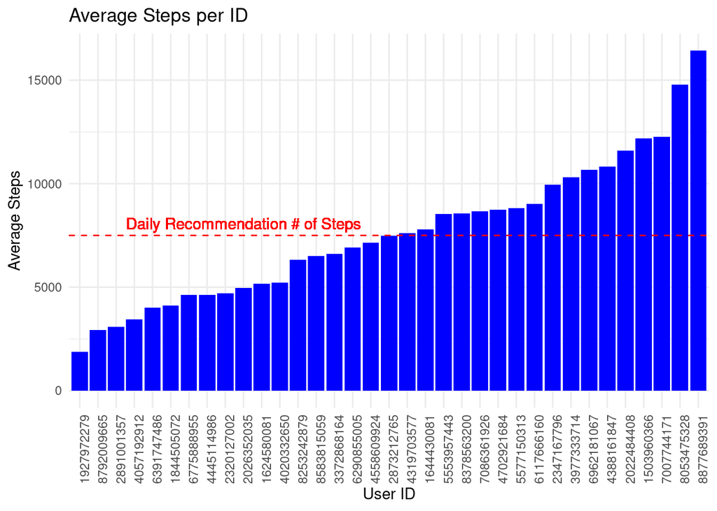

```r
ggplot(daily_activity_average, aes(x = reorder(id, mean_steps), y = mean_steps)) +
  geom_bar(stat = "identity", fill = "blue") +
  geom_hline(yintercept = 7500, linetype = "dashed", color = "red") +  # Add horizontal line at 7500
  geom_text(aes(x = 10, y = 7500, label = "Daily Recommendation # of Steps"),
            color = "red", angle = 0, vjust = -0.5) +  # Add label for the line
  labs(title = "Average Steps per ID",
       x = "User ID",
       y = "Average Steps") +
  theme_minimal() +
  theme(axis.text.x = element_text(angle = 90, hjust = 1))  # Rotate x-axis labels
```

Filtering out ID’s whose averages are under 7500 steps

```r
id_steps_under <- daily_activity_average %>%
  filter(mean_steps < 7500)
```

Counting the number of ID’s that are under 7500 steps

```r
num_steps_under <- nrow(id_steps_under)
```

Counting entire population of the dataset

```r
total_population <- nrow(daily_activity_average)
```

Creating a dataset that contains the number of people above the daily recommendation of 7500 steps and under 7500 steps.

```r
over_under_steps <- data.frame(
  category = c("Over 7500 Steps", "Under 7500 Steps"),
  count = c(num_steps_under, total_population - num_steps_under))
```

Plotting a pie chart to visualize the number of respondents from the survey to see if they are meeting daily recommendations.

[figure not shown]

```r
ggplot(over_under_steps,aes(x=" ", y= count, fill= category)) +
  geom_bar(stat = "identity", width = 1) +
  coord_polar(theta = "y") +
  ggtitle("Proportion of People with Average Steps Above and Under 7,500") +
  geom_text(aes(label = count),
            position = position_stack(vjust = 0.5),
            color = "black", size = 5) +
  theme_void()
```

Creating a new column stating day of the week. (ex. Jan 1, 2025 would become “Wednesday”)

```r
hourly_calories$day_of_week <- weekdays(hourly_calories$activity_hour)
```

Creating a new column stating the hour only.

```r
hourly_calories$time <- format(hourly_calories$activity_hour, "%H")
```

Creating a new data frame containing the day of the week and the hour of the day, and average calories burnt. This will show us the average calories burnt by the hour on each specific day of the week.

```r
hourly_calories_average <- hourly_calories %>%
  group_by(day_of_week,time) %>%
  summarise(average_calories_hourly = mean(calories))
```

Formatting the new column “time” to avoid data type issues when plotting.

```r
hourly_calories_average$time <- as.POSIXct(hourly_calories_average$time,format="%H")
```

Plotting the line chart. This showcases the Average Calories Burnt by the Hour which is grouped by the day of the week. This can give us a high level view if calories being burnt are consistent throughout the week and if users will need reminders to burn calories.

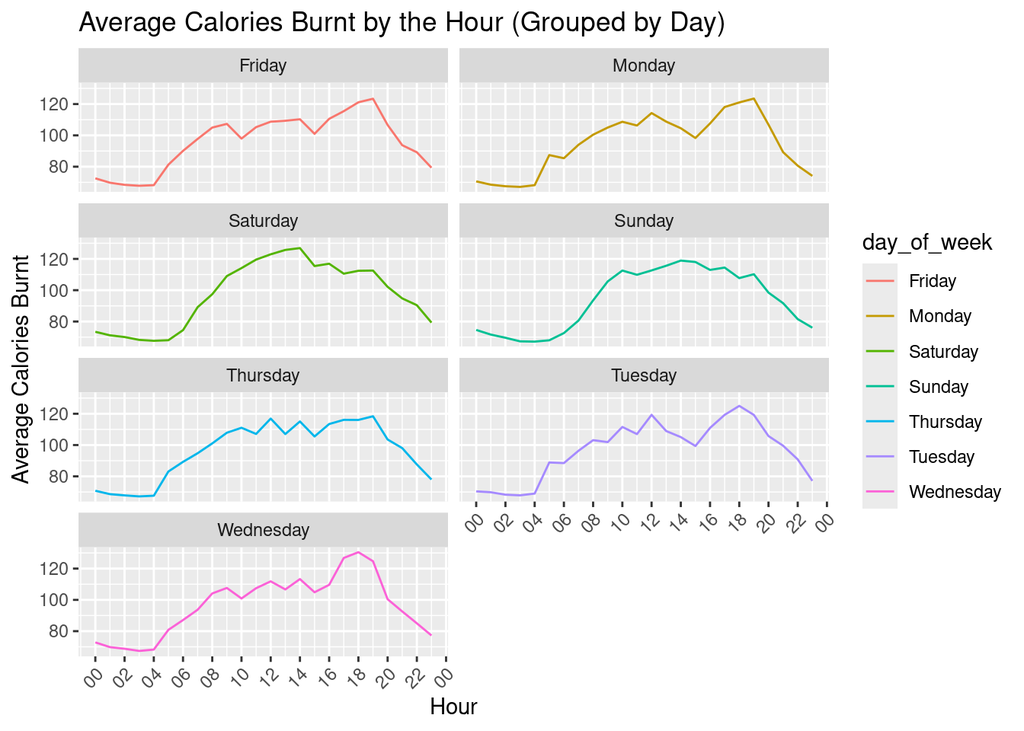

```r
ggplot(hourly_calories_average,aes(x=time, y= average_calories_hourly,group=day_of_week,color=day_of_week))+
  geom_line() +
  facet_wrap(~day_of_week, ncol=2) +
  labs(
    title = "Average Calories Burnt by the Hour (Grouped by Day)",
    x= "Hour",
    y= "Average Calories Burnt"
  ) +
  scale_x_datetime(date_labels = "%H", date_breaks = "2 hours") +
  theme(axis.text.x = element_text(angle=45, hjust = 1))
```

A data frame was created to transform the total number of minutes asleep to the average number of minutes asleep. By dividing by 60 we are able to convert minutes to hours.

```r
sleep_average <- day_sleep %>%
  group_by(id) %>%
  summarise(
    average_sleep = (mean(total_minutes_asleep)/60),
    average_time_in_bed= (mean(total_time_in_bed)/60))
```

A bar graph was plotted to determine how many ID’s were getting the recommended amount of sleep (7-8 Hours).

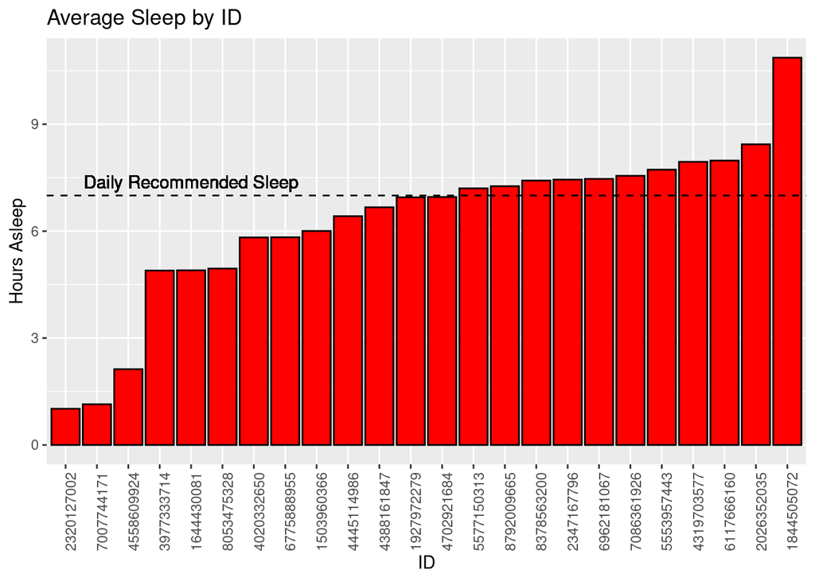

```r
ggplot(sleep_average, aes(x=reorder(id, average_sleep),y=average_sleep))+
  geom_bar(stat="identity", fill="red",color="black") +
  geom_hline(yintercept = 7, linetype = "dashed", color = "black") +
  geom_text(aes(x = 5, y = 7, label = "Daily Recommended Sleep"),
            color = "black", angle = 0, vjust = -0.5) +
  labs(
    title = "Average Sleep by ID",
    x = "ID",
    y = "Hours Asleep"
  ) +
  theme(axis.text.x=element_text(angle = 90, hjust =1))
```